# Integration Servicesを用いたデータ管理

2016年6月1日

## どんなお話？

SQL Serverの一機能であるIntegration Servicesというものを使ってデータ登録処理を楽にしたい、というお話です

## Integration Servicesとは

> SQL Server Integration Services (SSIS:データ転送サービス) とは、SQL Serverの標準機能として搭載されている、データの「コピー」や「変換」などが行える”データ転送ツール”です。

※但し、**SQL Server Standard**以上が必要(Expressだとほんの一部の機能しか使えない)

- **出来ること**
  - SQL ServerやOracle間とのデータ転送
  - CSVのインポート・エクスポート
  - Excelインポート・エクスポート
    - Office or 再頒布可能コンポーネントが必要
  - インポート・エクスポート時のデータ変換

## グラフィカル操作

[figure not shown]

## 実行方法

- dtexecUIでの実行
  - dtsxファイルをダブルクリック
- コマンドでの実行
  - dtexec /FILE hoge.dtsx 他パラメータ
- SQL Server Management Studioからの実行
  - SSMSのプロジェクトから右クリックから実行

コマンド実行はdtsxファイルの実行のほか、SQL Serverに発行したプロジェクトパッケージを実行することも可能

コマンドから実行できる⇒タスクでの実行も可能

## 実行時の同期・非同期制御

- コマンドから実行する場合、ParameterのSynchronizedをtrueに設定すると同期実行になる
  - dtexec /FILE hoge.dtsx /Parameter "$ServerOption::SYNCHRONIZED(Boolean)";True
  - 規定はfalse
    - そのまま実行すると結果を待たずに処理が返ってくる
- 参考
  - [Exit Codes, DTEXEC, and SSIS Catalog](http://www.mattmasson.com/2012/02/exit-codes-dtexec-and-ssis-catalog/)
  - [Server Execution Parameters with ETEXEC](http://www.mattmasson.com/2013/06/server-execution-parameters-with-dtexec/)

## 実行レポート－概要

[figure not shown]

## 実行レポート－詳細

[figure not shown]

## SQL Server上での管理

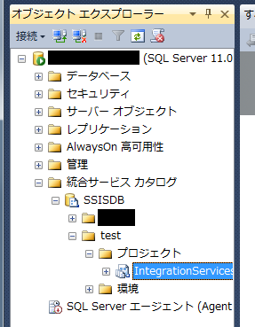

1. カタログという専用DBを用意
2. 管理単位でフォルダを作成可能
3. プロジェクト単位で管理可能

**SQL Serverでデータ登録・変換処理を管理可能に！！**

## 入門書

- Microsoft SQL Server 自習書
  - [Integration Services 入門](http://download.microsoft.com/download/5/A/2/5A29D047-2D83-4ACD-919F-4614847E8392/SQL11_SelfLearning07_SSIS1.pdf)
  - [Integration Services 応用](http://download.microsoft.com/download/5/A/2/5A29D047-2D83-4ACD-919F-4614847E8392/SQL11_SelfLearning08_SSIS2.pdf)